[figure not shown]

# Introduction à la Recherche Opérationelle

M2 Statistique Science des Données (SSD)

[Anatoli Juditsky](https://www-ljk.imag.fr/membres/Anatoli.Iouditski/)  
[Franck Iutzeler](http://www.iutzeler.org)

# Bineta FAYE & Florence PITTION & Marame DIAGNE

TP 4 - Classification

# Problème de classification et sélection de variables

Nous considérons le modèle suivant de classification (prédiction de 0 et 1) $$ y=\mathrm{sign}(X\theta+\sigma\xi),\;\;\xi\sim \mathcal{N}(0, I_m),$$ où $X\in \mathbb{R}^{m\times n}$ et $y\in \{-1,1\}^m$ sont les observables, et $\theta\in \mathbb{R}^n$ est le paramètre inconnu. $\mathrm{sign}(x) = -1 $ si $x<0$ et $+1$ si $x\geq 0$.

Nous allons voir plusieurs méthodes pour prédire $y$ et les comparer. Les fonctions utilisées sont toutes des combinaisons des fonctions CVXPY disponibles ici: https://www.cvxpy.org/tutorial/functions/index.html#scalar-functions

# Un exemple

```python
import cvxpy as cp
import numpy as np
%matplotlib inline
import matplotlib
import matplotlib.pyplot as plt
```

```python
# Exemple jouet
n = 4
m = 6
sigma = 0.1

X = np.random.randn(m,n) # matrice de mélange -- connue

theta0 = np.random.randn(n)
non_null_coordinates = np.random.choice(n, int(0.8*n), replace=False)
theta_true = np.zeros(n)
theta_true[non_null_coordinates] = theta0[non_null_coordinates] # vrai theta -- inconnu: à estimer

xi = np.random.randn(m) # bruit

y = np.sign(np.dot(X,theta_true) + sigma*xi) # observations -- connue
```

```python
X
```

```
array([[-0.25883503, -0.79893752,  1.02448015,  2.83765779],
       [ 0.36504412,  0.89554643, -1.90724637,  0.48886794],
       [-1.95144957,  0.97811811, -2.69537617, -0.59389761],
       [-0.98280179,  0.52044266,  0.48796076, -0.47007625],
       [-1.32831923,  0.58167257,  0.523246  ,  0.27684046],
       [-0.11782814, -0.36633618, -1.15336415,  1.4765011 ]])
```

```python
theta_true
```

```
array([ 0.        ,  0.20614216, -1.65130159, -1.83869352])
```

```python
y
```

```
array([-1.,  1.,  1., -1., -1., -1.])
```

# Estimateur A

Le premier estimateur que nous allons implémenter est le lasso:

\begin{equation} \tag{A} \theta_A \in \arg\min_\theta \left\{ \frac{1}{2} \| X\theta - y \|_2^2 + \lambda \|\theta\|_1 \right\}, \end{equation}

où $\lambda>0$ est le *paramètre de régularisation* qui controle le degré de parcimonie de la solution.

> **Question 1:** Écrivez une fonction `EstimateurA` qui retourne ${\theta}_{A}$.
> - Cette fonction qui prend en entrée:
>   - `X`
>   - `y`
>   - `lambda`
> - et sort les elements
>   - `coef`, vecteur des coefficients de regression
>   - `status`, le champ `status` de la solution du problème d'optimisation.

> Testez cette fonction sur l'exemple du début.

```python
### fonction A
def EstimateurA(X, y,lamda):
    n = X.shape[1]
    theta=cp.Variable(n)
    X1=cp.norm(X@theta-y,2)
    L = (1/2)*(X1**2) + lamda*cp.norm(theta,1)
    objective = cp.Minimize(L)
    prob = cp.Problem(objective)
    prob.solve()
    theta_ds = theta.value
    sol_status = prob.status
    return theta_ds,sol_status,prob.solve()
```

```python
### exemple
lamda=0.5
EstimateurA(X,y,lamda)
```

```
(array([ 3.02248893e-01, -1.13089813e-11, -3.95780695e-01, -2.85606460e-01]),
 'optimal',
 1.3905663221852993)
```

```python
theta_true
```

```
array([ 0.        ,  0.20614216, -1.65130159, -1.83869352])
```

# Estimateur B

Prenons un estimateur proche du sélecteur de Dantzig (TP2)

\begin{equation} \tag{B} \theta_B \in \arg\min_\theta \left\{ \|\theta\|_1 \text{ sous contrainte } \| X\theta - y \|_2^2 \leq \lambda \right\}, \end{equation}

où $\lambda>0$ est l'*erreur autorisée* qui restreint les solutions à être optimale à $\lambda$ près.

> **Question 2:** Écrivez une fonction `EstimateurB` qui retourne ${\theta}_{B}$.
> - Cette fonction qui prend en entrée:
>   - `X`
>   - `y`
>   - `lambda`
> - et sort les elements
>   - `coef`, vecteur des coefficients de regression
>   - `status`, le champ `status` de la solution du problème d'optimisation.

> Testez cette fonction sur l'exemple du début.

```python
def EstimateurB(X,y,lamda):
    n = X.shape[1]
    theta=cp.Variable(n)
    contrainte1 = (cp.norm((X@theta-y),2))**2<=lamda
    L = cp.norm(theta,1)
    objective = cp.Minimize(L)
    prob = cp.Problem(objective,constraints=[contrainte1])
    prob.solve()

    return theta.value,prob.status,prob.solve()
```

> **Question 3:** Testez l'estimateur B pour différentes valeurs de lambda. Le problème d'optimisation a-t-il toujours une solution? Expliquez.

```python
EstimateurB(X,y,0.16)
```

```
(None, 'infeasible', inf)
```

```python
EstimateurB(X,y,0.2)
```

```
(None, 'infeasible', inf)
```

```python
EstimateurB(X,y,0.3)
```

```
(None, 'infeasible', inf)
```

```python
EstimateurB(X,y,0.5)
```

```
(None, 'infeasible', inf)
```

```python
EstimateurB(X,y,0.7)
```

```
(None, 'infeasible', inf)
```

```python
EstimateurB(X,y,0.8)
```

```
(None, 'infeasible', inf)
```

```python
EstimateurB(X,y,2)
```

```
(array([ 2.25583876e-01,  4.08823581e-05, -3.54843331e-01, -2.55432522e-01]),
 'optimal',
 0.8359407330786235)
```

Pour l'estimateur B

```python
EstimateurB(X,y,5)
```

```
(array([ 6.11856244e-08, -3.86174060e-06, -1.04942994e-01, -9.28296201e-05]),
 'optimal',
 0.10505129573483764)
```

Pour des valeurs de lambda assez petite, le problème de minimisation n'a pas de solution, cela est lié à la contrainte : \begin{equation} \| X\theta - y \|_2^2 \leq \lambda \end{equation}

# Estimateur C

Au lieu de contraindre l'erreur, contraignons les valeurs du paramètre.

\begin{equation} \tag{C} \theta_C \in \arg\min_\theta \left\{ \| X\theta - y \|_2^2 \text{ sous contrainte } |\theta_i| \leq \lambda \text{ pour tout } i \right\}, \end{equation}

où $\lambda>0$ est la *norme maximale*.

> **Question 4:** Écrivez une fonction `EstimateurC` qui retourne ${\theta}_{C}$.
> - Cette fonction qui prend en entrée:
>   - `X`
>   - `y`
>   - `lambda`
> - et sort les elements
>   - `coef`, vecteur des coefficients de regression
>   - `status`, le champ `status` de la solution du problème d'optimisation.
>   - `dual`, la variable duale optimale

> Testez cette fonction sur l'exemple du début.

```python
abs(theta_true)<0.5
```

```
array([ True,  True, False, False])
```

```python
def EstimateurC(X,y,lamda):
    n = X.shape[1]

    theta=cp.Variable(n)
    contrainte = cp.abs(theta)<=lamda
    X1 = cp.norm((X@theta-y),2)
    L=X1**2
    objective = cp.Minimize(L)
    prob = cp.Problem(objective,constraints=[contrainte])
    prob.solve()
    dual=prob.constraints[0].dual_value
    return theta.value,prob.status,prob.solve(),dual
    ####
```

> **Question 5:** Faites varier lambda et utilisez la valeur de la variable duale pour déterminer si la contrainte est active ou inactive.

```python
EstimateurC(X,y,0.05)### active
```

```
(array([ 0.04999988,  0.04999917, -0.05      , -0.05000034]),
 'optimal',
 4.825141837088514,
 array([2.16739605, 3.09952807, 9.3194305 , 6.90978357]))
```

```python
EstimateurC(X,y,0.08)### active
```

```
(array([ 0.07999779,  0.08000469, -0.0799981 , -0.08000036]),
 'optimal',
 4.216277703293631,
 array([2.14621661, 2.63502831, 8.32914169, 5.98447684]))
```

```python
EstimateurC(X,y,0.09) ### active
```

```
(array([ 0.09000001,  0.09000004, -0.09      , -0.09000004]),
 'optimal',
 4.029329697214668,
 array([2.13910897, 2.48022615, 7.99904634, 5.67608484]))
```

```python
EstimateurC(X,y,1)### inactive
```

```
(array([ 0.44361244,  0.13919632, -0.42201324, -0.29501486]),
 'optimal',
 1.680377659754135,
 array([0., 0., 0., 0.]))
```

```python
EstimateurC(X,y,2)## inactive
```

```
(array([ 0.44361244,  0.13919632, -0.42201324, -0.29501486]),
 'optimal',
 1.6803776597541356,
 array([0., 0., 0., 0.]))
```

> **Question 6:** La solution $\theta_C$ est-elle toujours différente de la solution du problème des moindres carrés $\theta_{MoindresCarrés} \in \arg\min_\theta \left\{ \| X\theta - y \|_2^2 \right\}$ ?

```python
def MC(X, y):
    n = X.shape[1]
    theta=cp.Variable(n)
    X1=cp.norm(X@theta-y,2)
    L = X1**2
    objective = cp.Minimize(L)
    prob = cp.Problem(objective)
    prob.solve()
    theta_ds = theta.value
    sol_status = prob.status
    return theta_ds,sol_status,prob.solve()
```

```python
EstimateurC(X,y,0.08)
```

```
(array([ 0.07999779,  0.08000469, -0.0799981 , -0.08000036]),
 'optimal',
 4.216277703293631,
 array([2.14621661, 2.63502831, 8.32914169, 5.98447684]))
```

```python
EstimateurC(X,y,1)
```

```
(array([ 0.44361244,  0.13919632, -0.42201324, -0.29501486]),
 'optimal',
 1.680377659754135,
 array([0., 0., 0., 0.]))
```

```python
MC(X,y)##### égal à l'estimateur C pour lamda grand ( > 0.7)
```

```
(array([ 0.44361244,  0.13919632, -0.42201324, -0.29501486]),
 'optimal',
 1.6803776597541356)
```

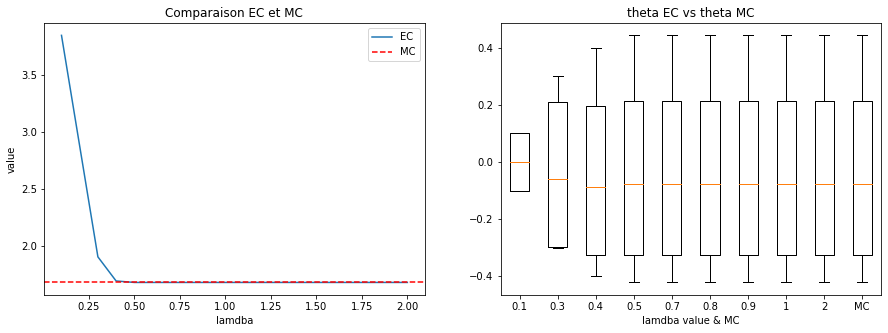

```python
#### On affiche la valeur de la fonction à minimiser en son minimun
lamda=[0.1,0.3,0.4,0.5,0.7,0.8,0.9,1,2]
lamda
th=[]
E_c=[]
for i in range(len(lamda)):
    E_c.append((EstimateurC(X,y,lamda[i]))[2])
    th.append((EstimateurC(X,y,lamda[i]))[0])

plt.subplots(figsize=(15, 5))
plt.subplot(1, 2, 1)
plt.plot(lamda,E_c,label="EC")
mc=MC(X,y)[2]
plt.axhline(y=mc,c="red",linestyle='--',label="MC")
plt.xlabel('lamdba')
plt.ylabel('value')
plt.title('Comparaison EC et MC')
plt.legend()
##############################
#### affichage de la convergence de l'estimateur c vers vers l'estimateur des moindres carrées
plt.subplot(1, 2, 2)
th.append(MC(X,y)[0])
l=lamda
l.append("MC")
plt.boxplot(th,labels=l)
plt.xlabel('lamdba value & MC')
plt.title('theta EC vs theta MC')
#plt.boxplot(mc)
plt.show()
```

# Comparison des estimateurs

Comparons maintenant les estimateurs ci-dessus à partir de l'exemple suivant:

```python
# Exemple plus grand
n = 60
m = 200
sigma = 0.1

X = np.random.randn(m,n) # matrice de mélange -- connue

theta0 = np.random.randn(n)
non_null_coordinates = np.random.choice(n, int(0.8*n), replace=False)
theta_true = np.zeros(n)
theta_true[non_null_coordinates] = theta0[non_null_coordinates] # vrai theta -- inconnu: à estimer

xi = np.random.randn(m) # bruit

y = np.sign(np.dot(X,theta_true) + sigma*xi) # observations -- connue
```

Divisons les données à moitié en jeu d'entrainement et moitié en jeu de test.

```python
X_train = X[:int(m/2),:]
y_train = y[:int(m/2)]

X_test = X[int(m/2):,:]
y_test = y[int(m/2):]
```

> **Question 7:** Pour chacun des estimateurs, trouvez la valeur de $\lambda$ pour laquelle l'estimateur (calculé sur les données d'entrainement) minimise l'erreur de classification (sur les données de test).

**Ex:** Pour l'estimateur A, on calcule `theta_A, = EstimateurA(X_train, y_train, lam = 1e-5 )` puis la prédiction $$ y_{A,pred} = \text{sign}(X_{test}\theta_A). $$ Puis l'erreur de classification s'écrit comme le pourcentage de coordonnées $i$ pour lesquelles $ y_{A,pred}(i) \neq y_{test}(i)$.

```python
### définition de la fonction sign

def sign(x):
    if x<0:
        return -1
    else:
        return 1
```

```python
#### on définit une fonction qui pour un lamda et un estimateur donné calcule l'erreur de prediction
def erreur_test(lamda,E):

    theta_E=E(X_train,y_train,lamda)[0]
    #theta_E
    x=np.dot(X_test,theta_E)
    s=[]
    ## sign de X_test*thetaA
    for i in range(len(x)):
            s.append(sign(x[i]))
    y_pred=np.array(s)
    #calcul du poucentage ou de l'erreur
    s=0
    for i in range(len(y_pred)):
        if y_pred[i]!=y_test[i]:
            s=s+1

    return s/len(y_pred)
```

```python
erreur_test(10**(-5),EstimateurA)
```

```
0.17
```

```python
#### lamda minimisant l'erreur pour EstimateurA
lamda=np.linspace(0,2)
err=[]
for i in range(len(lamda)):
            err.append(erreur_test(lamda[i],EstimateurA))

i=np.argmin(err)
er_A=err[i]
lamda_op_A=lamda[i]
lamda_op_A
theta_A=EstimateurA(X_train,y_train,lamda_op_A)[0]
print("le lambda minimisant l'erreur de prediction de l'estimateur A sur le jeu de données test est ",lamda_op_A)
```

```
le lambda minimisant l'erreur de prediction de l'estimateur A sur le jeu de données test est  1.8775510204081631
```

```python
#erreur_test(17,EstimateurB)
lamda=np.linspace(20,30)
err=[]
for i in range(len(lamda)):
            err.append(erreur_test(lamda[i],EstimateurB))
#err
i=np.argmin(err)
lamda_op_B=lamda[i]
er_B=err[i]
theta_B=EstimateurA(X_train,y_train,lamda_op_B)[0]
print("le lambda minimisant l'erreur de prediction de l'estimateur B sur le jeu de données test est ",lamda_op_B)
```

```
le lambda minimisant l'erreur de prediction de l'estimateur B sur le jeu de données test est  21.020408163265305
```

```python
### Estimateur C
lamda=np.linspace(0,2)
err=[]
for i in range(len(lamda)):
            err.append(erreur_test(lamda[i],EstimateurC))

i=np.argmin(err)
er_C=err[i]
lamda_op_C=lamda[i]
lamda_op_C
theta_C=EstimateurA(X_train,y_train,lamda_op_C)[0]
print("le lambda minimisant l'erreur de prediction de l'estimateur C sur le jeu de données test est ",lamda_op_C)
```

```
le lambda minimisant l'erreur de prediction de l'estimateur C sur le jeu de données test est  0.24489795918367346
```

> **Question 8:** Comparez les quatre estimateurs. (Cette question est volontairement ouverte, plusieurs critères peuvent être utilisés, des propositions d'améliorations peuvent etre formulées.)

```python
### calcul de l'erreur pour MC
theta_MC=MC(X_train,y_train)[0]
#theta_E
x=np.dot(X_test,theta_MC)
s=[]
## sign de X_test*thetaA
for i in range(len(x)):
        s.append(sign(x[i]))
y_pred=np.array(s)
#calcul du poucentage ou de l'erreur
s=0
for i in range(len(y_pred)):
    if y_pred[i]!=y_test[i]:
        s=s+1

er_MC=s/len(y_pred)
```

On regarde ici l'erreur de prédiction des estimateurs pour le lambda trouvé dans la question précedente.

```python
###
import pandas as pd
S=[er_A,er_B,er_C,er_MC]
Err=pd.DataFrame(S,columns=['Erreur'],index=["Estimateur A","Estimateur B","Estimateur C","Estimateur MC"])
Err
```

|  | Erreur |
| --- | --- |
| Estimateur A | 0.13 |
| Estimateur B | 0.13 |
| Estimateur C | 0.16 |
| Estimateur MC | 0.17 |

L'estimateur qui fait le moins d'erreur sur le jeu de test peut être considéré comme le meilleur.\ Donc si on ne regarde que l'erreur de prédiction, on peut classer les estimateurs du meilleur au pire comme suit:

```python
print(Err.sort_values(by = 'Erreur'))
```

```
               Erreur
Estimateur A     0.13
Estimateur B     0.13
Estimateur C     0.16
Estimateur MC    0.17
```

Maintenant nous allons regarder l'estimateur qui se rapproche le plus de theta_true

```python
theta_Est=[theta_A,theta_B,theta_C,theta_MC,theta_true]
```

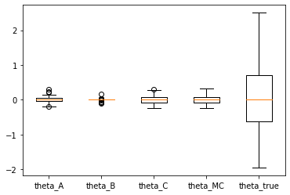

```python
plt.boxplot(theta_Est,labels=["theta_A","theta_B","theta_C","theta_MC","theta_true"])
plt.show()
```

Comme autres pistes de comparaison nous avons regader la distribution des différents theta par rapport au vecteur theta true mais la comparaison ne permet pas de conclure.\ Nous avons aussi pensez à comparer les estimateurs avec un lambda fixé mais les lambda selon les estimateurs n'ont pas la même signification docn cela ne nous à pas paru pertinent.

Concernant les pistes d'amelioration nous pensons qu'il faut comparer ces estimateurs en les testant sur un plus grand jeu de données.\ Pour optimiser la phase d'apprentissage il faudrait utiliser un meilleur partitionnement jeu d'entrainement/ jeu de test et mieux encore faire une validation croisée.

Il faudrait aussi faire varier les dimensions des matrices pour tester le comportement des estimateurs avec plus de variables que de lignes. Afin de de voir quel estimateur est le plus adapté à chaque situation.